# Kelp! I Need Somebody…

Benjamin Cassidy

1/28/2020

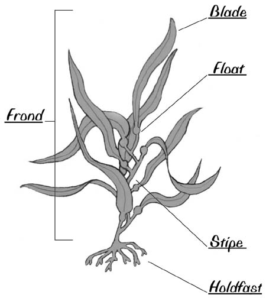

Parts of Kelp

## Set-up Documentation - Packages

```r
library(tidyverse) #install.packages("tidyverse")
library(readxl) #install.packages("readxl")
library(here) #install.packages("here")
library(kableExtra) #install.packages("kableExtra")
#library(skimr) #install.packages("skimr")
#library(janitor) #install.packages("janitor")

library(ggthemes)#install.packages("ggthemes")
```

## Data

```r
fish <- read.csv(here("data","fish.csv"))

kelp_abur <- read_excel(here("data","kelp_fronds.xlsx"),
                        sheet = "abur")

fish
```

```
##    year site     common_name total_count
## 1  2016 abur black surfperch           2
## 2  2016 abur      blacksmith           1
## 3  2016 abur       garibaldi           1
## 4  2016 abur     rock wrasse           2
## 5  2016 abur        senorita          58
## 6  2016 aque black surfperch           1
## 7  2016 aque      blacksmith           1
## 8  2016 aque       garibaldi           1
## 9  2016 aque     rock wrasse           1
## 10 2016 aque        senorita          57
## 11 2016 mohk black surfperch           1
## 12 2016 mohk      blacksmith           1
## 13 2016 mohk       garibaldi           2
## 14 2016 mohk     rock wrasse          17
```

[output cut: 31 more lines]

```r
kelp_abur
```

```
## # A tibble: 3 x 4
##    year month site  total_fronds
##   <dbl> <dbl> <chr>        <dbl>
## 1  2016     7 abur            23
## 2  2017     7 abur            17
## 3  2018     7 abur          1155
```

## Filtering Features

Exact match: `==`

#### Example 1: Only keep obs form `fish` that has obs of `garibaldi`

```r
fish_garibaldi <- fish %>%
  filter(common_name == "garibaldi")

fish_garibaldi
```

```
##   year site common_name total_count
## 1 2016 abur   garibaldi           1
## 2 2016 aque   garibaldi           1
## 3 2016 mohk   garibaldi           2
## 4 2017 abur   garibaldi           1
## 5 2017 aque   garibaldi           1
## 6 2017 mohk   garibaldi           6
## 7 2018 abur   garibaldi           1
## 8 2018 aque   garibaldi           1
## 9 2018 mohk   garibaldi          10
```

Other operators `>,<,>=,<=`

#### Example 2: Only keep obs with 50 or greater

```r
filter_over_fifty <- fish %>%
  filter(total_count >= 50)


filter_over_fifty
```

```
##   year site     common_name total_count
## 1 2016 abur        senorita          58
## 2 2016 aque        senorita          57
## 3 2017 abur     rock wrasse          57
## 4 2017 abur        senorita          64
## 5 2017 mohk black surfperch          50
```

Using `OR` statement filters

Can use the `|` for `OR` operators

#### Example 3: Use OR to find `garibaldi|blacksmith`

```r
fish2spec <- fish %>%
  filter(common_name == 'garibaldi'|common_name =='blacksmith')

fish2spec
```

```
##    year site common_name total_count
## 1  2016 abur  blacksmith           1
## 2  2016 abur   garibaldi           1
## 3  2016 aque  blacksmith           1
## 4  2016 aque   garibaldi           1
## 5  2016 mohk  blacksmith           1
## 6  2016 mohk   garibaldi           2
## 7  2017 abur  blacksmith           1
## 8  2017 abur   garibaldi           1
## 9  2017 aque  blacksmith           1
## 10 2017 aque   garibaldi           1
## 11 2017 mohk  blacksmith           8
## 12 2017 mohk   garibaldi           6
## 13 2018 abur  blacksmith           1
## 14 2018 abur   garibaldi           1
## 15 2018 aque  blacksmith           1
## 16 2018 aque   garibaldi           1
## 17 2018 mohk  blacksmith          31
## 18 2018 mohk   garibaldi          10
```

Using the `%in%` operator

Matches against a vector with multiple values

```r
fish_sp <- c('garibaldi','blacksmith','black surfperch')

fish_3sp <- fish %>%
    filter(common_name %in% fish_sp)


fish_3sp
```

```
##    year site     common_name total_count
## 1  2016 abur black surfperch           2
## 2  2016 abur      blacksmith           1
## 3  2016 abur       garibaldi           1
## 4  2016 aque black surfperch           1
## 5  2016 aque      blacksmith           1
## 6  2016 aque       garibaldi           1
## 7  2016 mohk black surfperch           1
## 8  2016 mohk      blacksmith           1
## 9  2016 mohk       garibaldi           2
## 10 2017 abur black surfperch           4
## 11 2017 abur      blacksmith           1
## 12 2017 abur       garibaldi           1
## 13 2017 aque black surfperch           1
## 14 2017 aque      blacksmith           1
## 15 2017 aque       garibaldi           1
## 16 2017 mohk black surfperch          50
## 17 2017 mohk      blacksmith           8
## 18 2017 mohk       garibaldi           6
## 19 2018 abur black surfperch           1
## 20 2018 abur      blacksmith           1
## 21 2018 abur       garibaldi           1
## 22 2018 aque black surfperch           2
## 23 2018 aque      blacksmith           1
## 24 2018 aque       garibaldi           1
## 25 2018 mohk black surfperch          32
## 26 2018 mohk      blacksmith          31
## 27 2018 mohk       garibaldi          10
```

#### Example 4: Match year 2016, or the common_name is `garibaldi`

```r
fish_sp_yr <- fish %>%
  filter(year == '2016' | common_name == 'garibaldi')

fish_sp_yr
```

```
##    year site     common_name total_count
## 1  2016 abur black surfperch           2
## 2  2016 abur      blacksmith           1
## 3  2016 abur       garibaldi           1
## 4  2016 abur     rock wrasse           2
## 5  2016 abur        senorita          58
## 6  2016 aque black surfperch           1
## 7  2016 aque      blacksmith           1
## 8  2016 aque       garibaldi           1
## 9  2016 aque     rock wrasse           1
## 10 2016 aque        senorita          57
## 11 2016 mohk black surfperch           1
## 12 2016 mohk      blacksmith           1
## 13 2016 mohk       garibaldi           2
## 14 2016 mohk     rock wrasse          17
## 15 2016 mohk        senorita           4
## 16 2017 abur       garibaldi           1
## 17 2017 aque       garibaldi           1
## 18 2017 mohk       garibaldi           6
## 19 2018 abur       garibaldi           1
## 20 2018 aque       garibaldi           1
## 21 2018 mohk       garibaldi          10
```

Using the `&` operator

May use `&` or `,`

```r
fish_aq_18 <- fish %>%
  filter(year == '2018' & site == 'aque')

fish_aq_18
```

```
##   year site     common_name total_count
## 1 2018 aque black surfperch           2
## 2 2018 aque      blacksmith           1
## 3 2018 aque       garibaldi           1
## 4 2018 aque     rock wrasse           4
## 5 2018 aque        senorita          36
```

To exclude things – `!=` operator

Same deal. No example.

## Using `stringr::str_dectect()`

Finding stuff **like** a value with `str_dectect()`

```r
blk_fish <- fish %>%
  filter(stringr::str_detect(
    common_name, pattern = "black"
  ))

blk_fish
```

```
##    year site     common_name total_count
## 1  2016 abur black surfperch           2
## 2  2016 abur      blacksmith           1
## 3  2016 aque black surfperch           1
## 4  2016 aque      blacksmith           1
## 5  2016 mohk black surfperch           1
## 6  2016 mohk      blacksmith           1
## 7  2017 abur black surfperch           4
## 8  2017 abur      blacksmith           1
## 9  2017 aque black surfperch           1
## 10 2017 aque      blacksmith           1
## 11 2017 mohk black surfperch          50
## 12 2017 mohk      blacksmith           8
## 13 2018 abur black surfperch           1
## 14 2018 abur      blacksmith           1
## 15 2018 aque black surfperch           2
## 16 2018 aque      blacksmith           1
## 17 2018 mohk black surfperch          32
## 18 2018 mohk      blacksmith          31
```

#### Example 5: Subset by string `it`

```r
it_fish <- fish %>%
  filter(stringr::str_detect(
    common_name, pattern = "it"
  ))

it_fish
```

```
##    year site common_name total_count
## 1  2016 abur  blacksmith           1
## 2  2016 abur    senorita          58
## 3  2016 aque  blacksmith           1
## 4  2016 aque    senorita          57
## 5  2016 mohk  blacksmith           1
## 6  2016 mohk    senorita           4
## 7  2017 abur  blacksmith           1
## 8  2017 abur    senorita          64
## 9  2017 aque  blacksmith           1
## 10 2017 aque    senorita           1
## 11 2017 mohk  blacksmith           8
## 12 2017 mohk    senorita          31
## 13 2018 abur  blacksmith           1
## 14 2018 abur    senorita           1
## 15 2018 aque  blacksmith           1
## 16 2018 aque    senorita          36
## 17 2018 mohk  blacksmith          31
## 18 2018 mohk    senorita           4
```

## Joins to merge df

Creates opportunities to make deliberate choices about a new table

Option 1: - `full_join` - gives a complete merge; these are the same as SQL - `full_join(x,y, by = c("Species","Year"))`

#### Example 1: use the abur df to merge to fish df with full merge on `year` and `site`

```r
abur_kelfish <- kelp_abur %>%
  full_join(fish, by = c("year","site"))
abur_kelfish
```

```
## # A tibble: 45 x 6
##     year month site  total_fronds common_name     total_count
##    <dbl> <dbl> <chr>        <dbl> <fct>                 <int>
##  1  2016     7 abur            23 black surfperch           2
##  2  2016     7 abur            23 blacksmith                1
##  3  2016     7 abur            23 garibaldi                 1
##  4  2016     7 abur            23 rock wrasse               2
##  5  2016     7 abur            23 senorita                 58
##  6  2017     7 abur            17 black surfperch           4
##  7  2017     7 abur            17 blacksmith                1
##  8  2017     7 abur            17 garibaldi                 1
##  9  2017     7 abur            17 rock wrasse              57
## 10  2017     7 abur            17 senorita                 64
## # ... with 35 more rows
```

Option 2: - `left_join` - gives a match from 2nd df only if on the 1st df - `left_join(x,y, by = c("Species","Year"))`

#### Example 2: use the abur df to merge to fish df with left merge on `year` and `site`

```r
left_kelfish <- kelp_abur %>%
  left_join(fish, by = c("year","site"))
left_kelfish
```

```
## # A tibble: 15 x 6
##     year month site  total_fronds common_name     total_count
##    <dbl> <dbl> <chr>        <dbl> <fct>                 <int>
##  1  2016     7 abur            23 black surfperch           2
##  2  2016     7 abur            23 blacksmith                1
##  3  2016     7 abur            23 garibaldi                 1
##  4  2016     7 abur            23 rock wrasse               2
##  5  2016     7 abur            23 senorita                 58
##  6  2017     7 abur            17 black surfperch           4
##  7  2017     7 abur            17 blacksmith                1
##  8  2017     7 abur            17 garibaldi                 1
##  9  2017     7 abur            17 rock wrasse              57
## 10  2017     7 abur            17 senorita                 64
## 11  2018     7 abur          1155 black surfperch           1
## 12  2018     7 abur          1155 blacksmith                1
## 13  2018     7 abur          1155 garibaldi                 1
## 14  2018     7 abur          1155 rock wrasse               1
## 15  2018     7 abur          1155 senorita                  1
```

Option 3: - `right_join` - gives a match from 1st df only if on the 2nd df - `right_join(x,y, by = c("Species","Year"))`

No example;

Option 4: - `inner_join` - gives a match with complete match on both - `inner_join(x,y, by = c("Species","Year"))`

#### Example 3: use the abur df to merge to fish df with inner merge on `year` and `site`

```r
inner_kelfish <- kelp_abur %>%
  inner_join(fish, by = c("year","site"))
inner_kelfish
```

```
## # A tibble: 15 x 6
##     year month site  total_fronds common_name     total_count
##    <dbl> <dbl> <chr>        <dbl> <fct>                 <int>
##  1  2016     7 abur            23 black surfperch           2
##  2  2016     7 abur            23 blacksmith                1
##  3  2016     7 abur            23 garibaldi                 1
##  4  2016     7 abur            23 rock wrasse               2
##  5  2016     7 abur            23 senorita                 58
##  6  2017     7 abur            17 black surfperch           4
##  7  2017     7 abur            17 blacksmith                1
##  8  2017     7 abur            17 garibaldi                 1
##  9  2017     7 abur            17 rock wrasse              57
## 10  2017     7 abur            17 senorita                 64
## 11  2018     7 abur          1155 black surfperch           1
## 12  2018     7 abur          1155 blacksmith                1
## 13  2018     7 abur          1155 garibaldi                 1
## 14  2018     7 abur          1155 rock wrasse               1
## 15  2018     7 abur          1155 senorita                  1
```

## Multi-step Plumbing

Best practice to check between each step

### Create object for fish_joined for only abur, 2017

```r
fish_joined <- fish %>%
  filter(year == '2017' & site == 'abur')

fish_joined
```

```
##   year site     common_name total_count
## 1 2017 abur black surfperch           4
## 2 2017 abur      blacksmith           1
## 3 2017 abur       garibaldi           1
## 4 2017 abur     rock wrasse          57
## 5 2017 abur        senorita          64
```

join to the kelp_abur data with left join

```r
left_fish_kelp <- fish_joined %>%
  left_join(kelp_abur, by = c("year","site"))
left_fish_kelp
```

```
##   year site     common_name total_count month total_fronds
## 1 2017 abur black surfperch           4     7           17
## 2 2017 abur      blacksmith           1     7           17
## 3 2017 abur       garibaldi           1     7           17
## 4 2017 abur     rock wrasse          57     7           17
## 5 2017 abur        senorita          64     7           17
```

add new column to calculate fish per kelp density(total_count/total_fronds

```r
dense_fish_kelp <- left_fish_kelp %>%
  mutate(fish_per_frond = total_count/total_fronds)

dense_fish_kelp
```

```
##   year site     common_name total_count month total_fronds fish_per_frond
## 1 2017 abur black surfperch           4     7           17     0.23529412
## 2 2017 abur      blacksmith           1     7           17     0.05882353
## 3 2017 abur       garibaldi           1     7           17     0.05882353
## 4 2017 abur     rock wrasse          57     7           17     3.35294118
## 5 2017 abur        senorita          64     7           17     3.76470588
```

make a kabletable

```r
dense_fish_kelp %>%
  kable() %>%
  kable_styling(bootstrap_options =
                  "striped",
                full_width = FALSE)
```

| year | site | common_name | total_count | month | total_fronds | fish_per_frond |
| --- | --- | --- | --- | --- | --- | --- |
| 2017 | abur | black surfperch | 4 | 7 | 17 | 0.2352941 |
| 2017 | abur | blacksmith | 1 | 7 | 17 | 0.0588235 |
| 2017 | abur | garibaldi | 1 | 7 | 17 | 0.0588235 |
| 2017 | abur | rock wrasse | 57 | 7 | 17 | 3.3529412 |
| 2017 | abur | senorita | 64 | 7 | 17 | 3.7647059 |

make a column graph with x=common_name, y=fish_per_frond

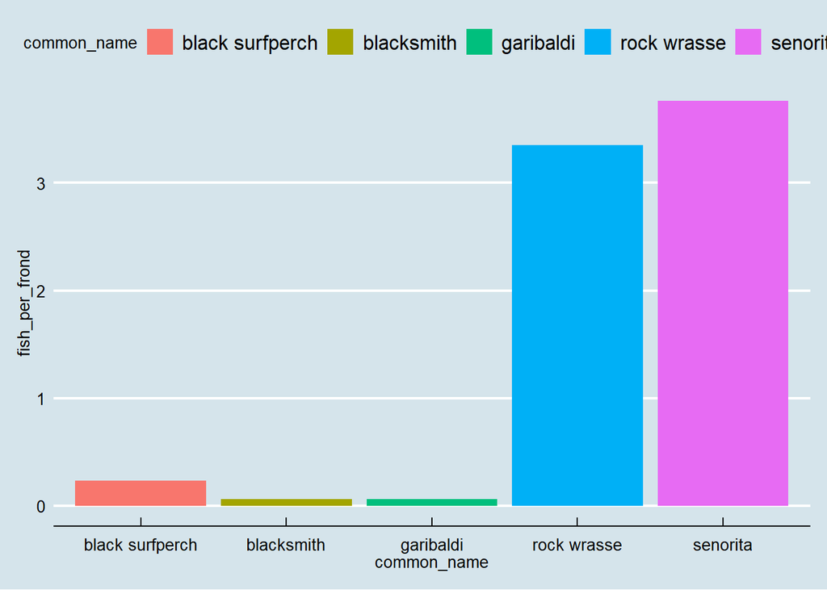

```r
ggplot(dense_fish_kelp,
       aes(x = common_name,y = fish_per_frond)) +
         geom_col(aes(fill = common_name)) +
          theme_economist(base_size = 10, base_family = "sans",
horizontal = TRUE, dkpanel = FALSE)
```